# ggplot2 Elegant Graphics for Data Analysis

홍우헌

quasar103@naver.com

2018-06-24

> Chapter 6  
> Scales, Axes and Legends

# 1 Modifying Scales

`ggplot(mpg, aes(displ, hwy)) + geom_point(aes(colour = class))` 이 코드가 사실은 `ggplot(mpg, aes(displ, hwy)) + geom_point(aes(colour = class)) + scale_x_continuous() + scale_y_continuous() + scale_colour_discrete()`

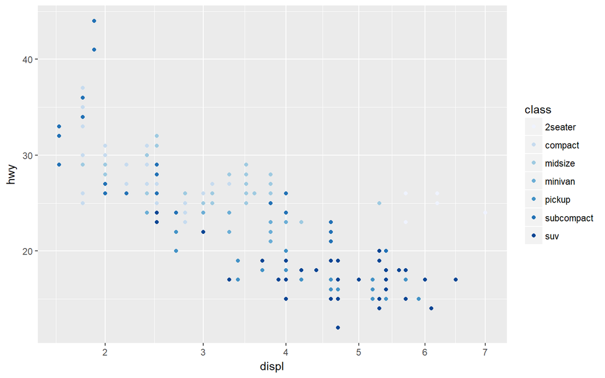

```r
ggplot(mpg, aes(displ, hwy)) +
  geom_point(aes(colour = class)) +
  scale_x_sqrt() +
  scale_colour_brewer()
```

1. scale
2. The name of the aesthetic(e.g., colour, shape or x)
3. The name of the scale(e.g., continuous, discrete, brewer)

# 2 Guides : Legends and Axes

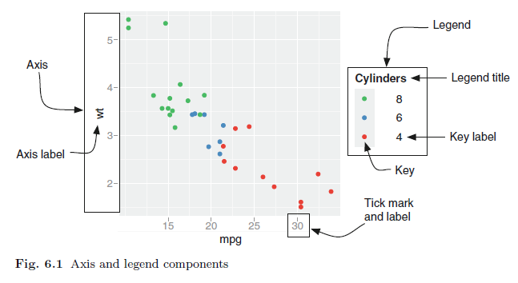

## 2.1 Scale Title

scale함수의 첫번째 인자는 named이다. 문자열()이나 수식을 quote()로 사용가능

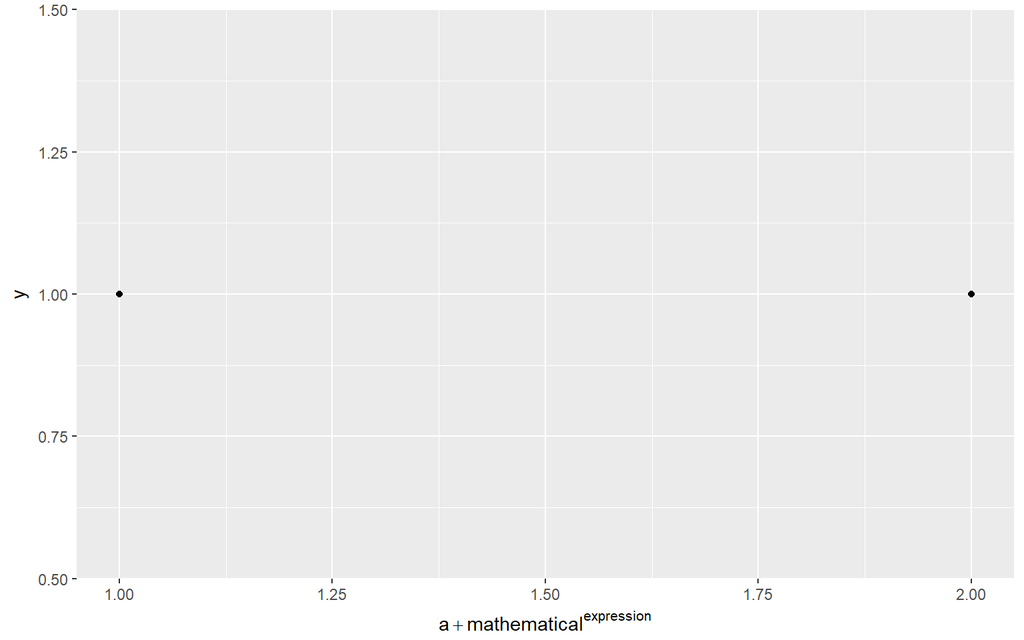

```r
df <- data.frame(x = 1:2, y = 1, z = "a")
p <- ggplot(df, aes(x, y)) + geom_point()
p + scale_x_continuous(quote(a + mathematical ^ expression))
```

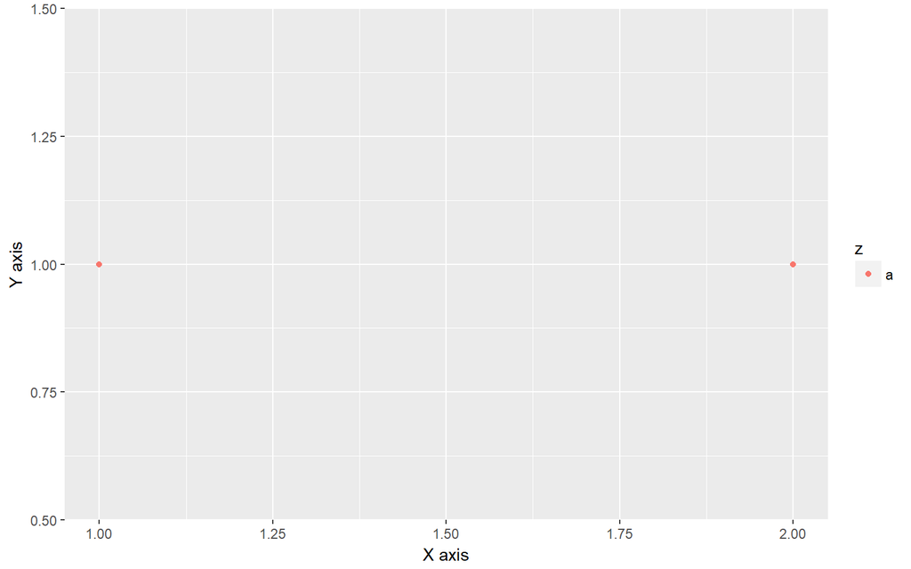

```r
p <- ggplot(df, aes(x, y)) + geom_point(aes(colour = z))
p +
  xlab("X axis") +
  ylab("Y axis")
```

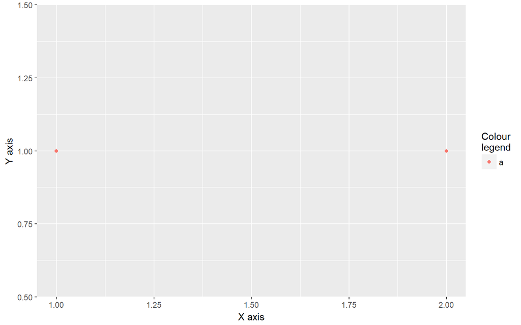

```r
p + labs(x = "X axis", y = "Y axis", colour = "Colour\nlegend") # \n사용에 주목
```

axis label 제거 방법에는 두가지가 있다. “”(공간이 남아있음)와 NULL이다.

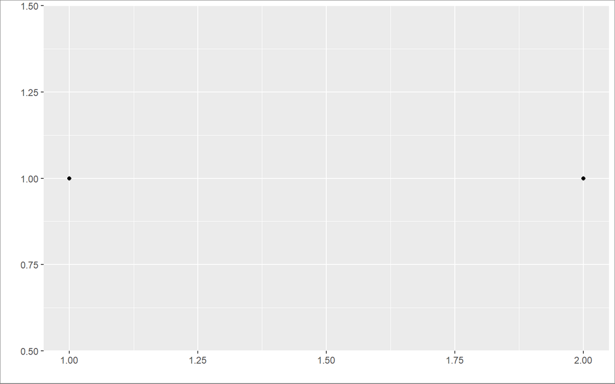

```r
p <- ggplot(df, aes(x, y)) +
geom_point() +
theme(plot.background = element_rect(colour = "grey50"))
p + labs(x = "", y = "")
```

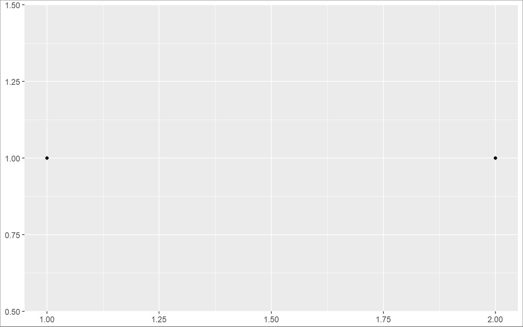

```r
p + labs(x = NULL, y = NULL)
```

## 2.2 Breaks and Labels

`breaks` 인자는 값이 축의 눈금과 범례의 key로써 나타내어짐을 통제한다. 각 break는 관련된 레이블을 가지고 있는데 `labels` 인자에 의해 통제된다. 만약 `labels`을 설정한다면 반드시 `breaks`도 설정해야 한다. 그렇지 않다면 데이터가 변한다면, breaks는 labels과 일치하지 않을 것이다.

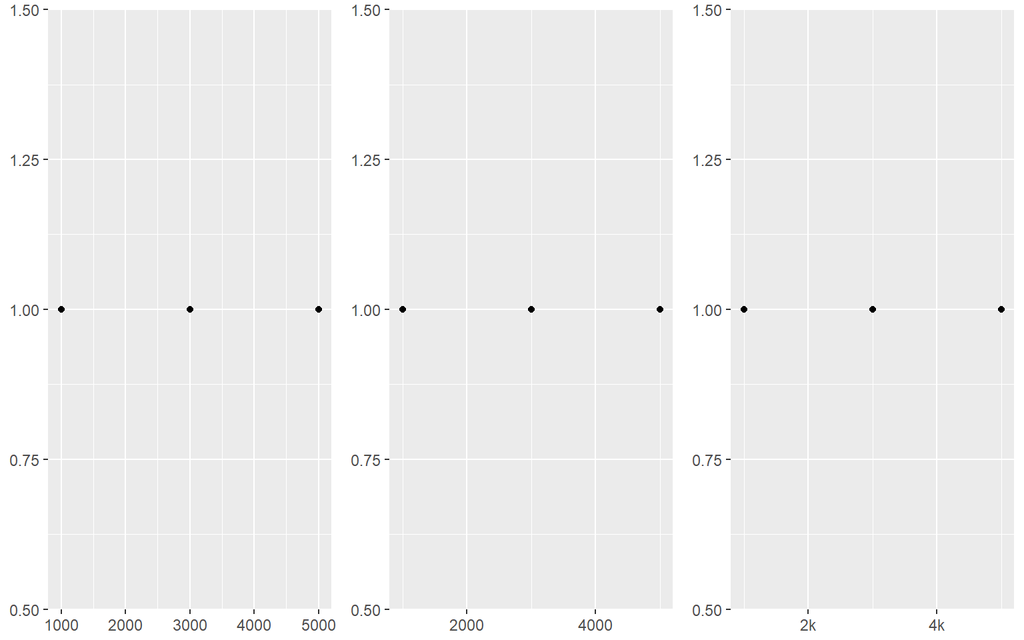

```r
df <- data.frame(x = c(1, 3, 5) * 1000, y = 1)
axs <- ggplot(df, aes(x, y)) +
  geom_point() +
  labs(x = NULL, y = NULL)
grid.arrange(axs,
axs + scale_x_continuous(breaks = c(2000, 4000)),
axs + scale_x_continuous(breaks = c(2000, 4000), labels = c("2k", "4k")), ncol = 3)
```

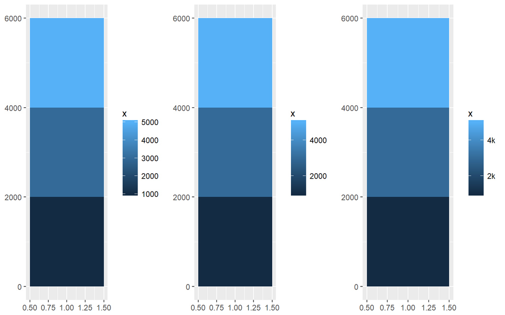

```r
leg <- ggplot(df, aes(y, x, fill = x)) +
  geom_tile() +
  labs(x = NULL, y = NULL)
grid.arrange(leg,
leg + scale_fill_continuous(breaks = c(2000, 4000)),
leg + scale_fill_continuous(breaks = c(2000, 4000), labels = c("2k", "4k")), ncol = 3)
```

범주형 스케일에서 breaks를 relabel하고자 한다면, labels vecotr를 사용할 수 있다.

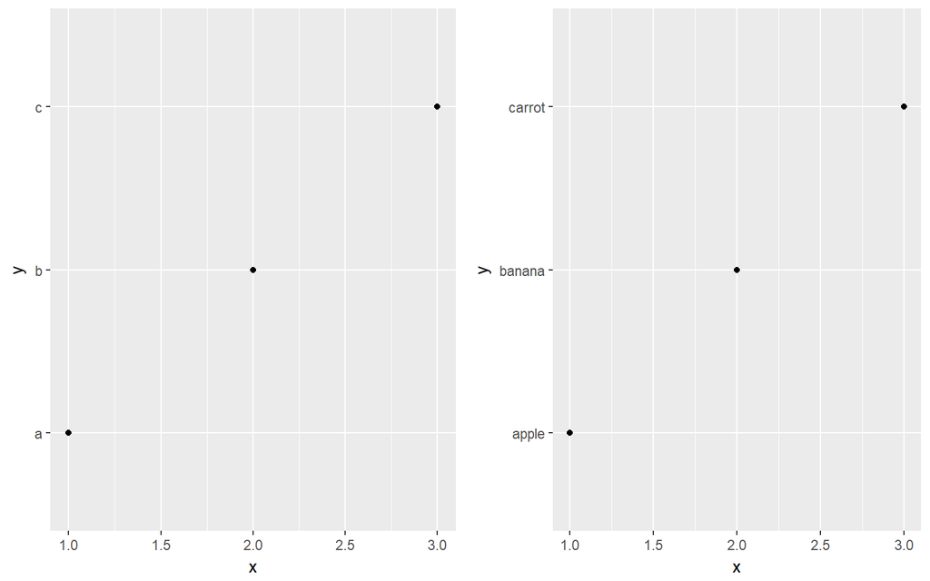

```r
df2 <- data.frame(x = 1:3, y = c("a", "b", "c"))
grid.arrange(ggplot(df2, aes(x, y)) +
  geom_point(),
ggplot(df2, aes(x, y)) +
  geom_point() +
  scale_y_discrete(labels = c(a = "apple", b = "banana", c = "carrot")), ncol = 2)
```

이렇게 제거하면 된다. breaks 제거시 label과 축과 범례가 함께 사라진다.

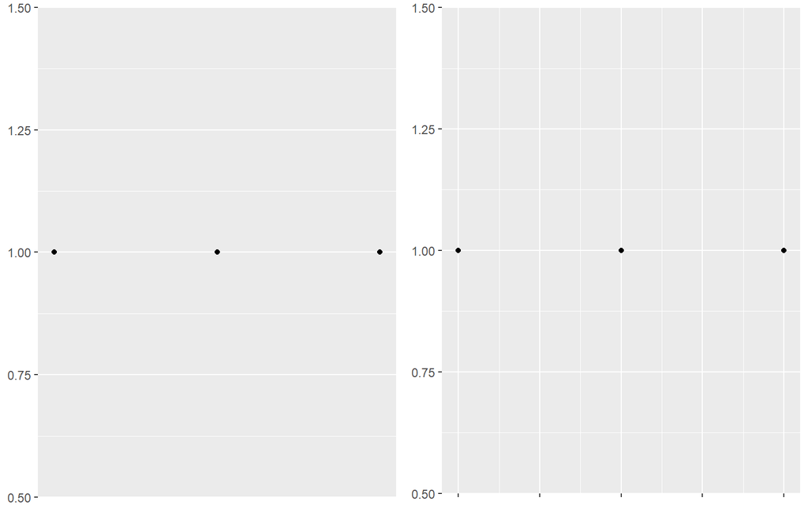

```r
grid.arrange(axs + scale_x_continuous(breaks = NULL),
axs + scale_x_continuous(labels = NULL), ncol = 2)
```

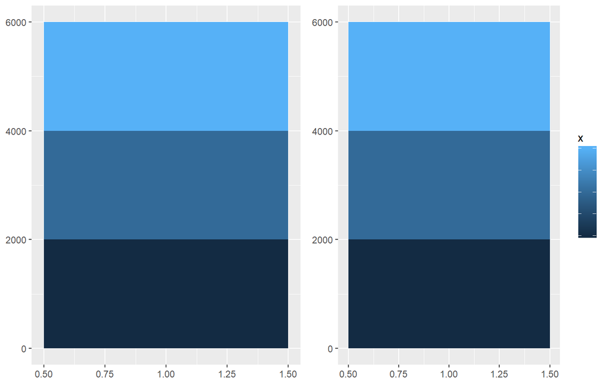

```r
grid.arrange(leg + scale_fill_continuous(breaks = NULL),
leg + scale_fill_continuous(labels = NULL), ncol = 2)
```

scales 패키지는 다수의 유용한 라벨링 함수를 제공한다.

- scales::coma_format() adds commas to make it easier to read large numbers.
- scales::unit_format(unit, scale) adds a unit suffix, optionally scaling.
- scales::dollar_format(prefix, suffix) displays currency values, rounding to two decimal places and adding a prefix or suffix
- scales::wrap_format() wraps long labels into multiple lines
- scales::ordinal() : 1st, 2nd, 3rd, …로 나타낸다.

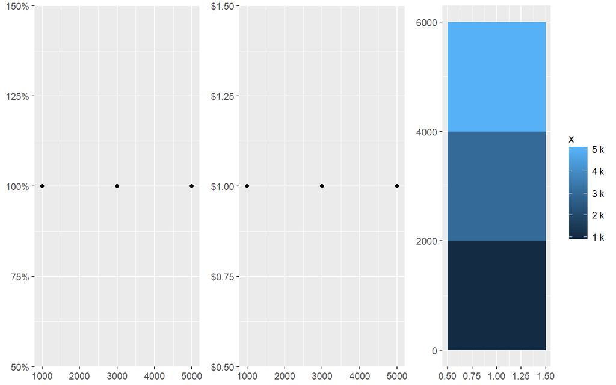

```r
grid.arrange(axs + scale_y_continuous(labels = scales::percent_format()),
axs + scale_y_continuous(labels = scales::dollar_format("$")),
leg + scale_fill_continuous(labels = scales::unit_format("k", 1e-3)), ncol = 3)
```

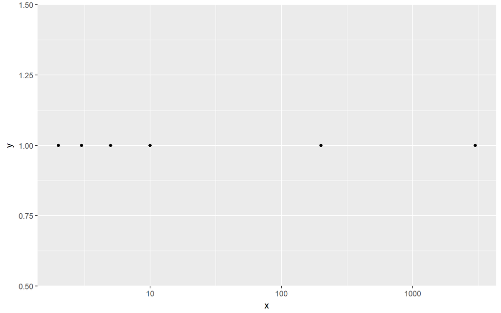

```r
df <- data.frame(x = c(2, 3, 5, 10, 200, 3000), y = 1)
ggplot(df, aes(x, y)) +
  geom_point() +
  scale_x_log10()
```

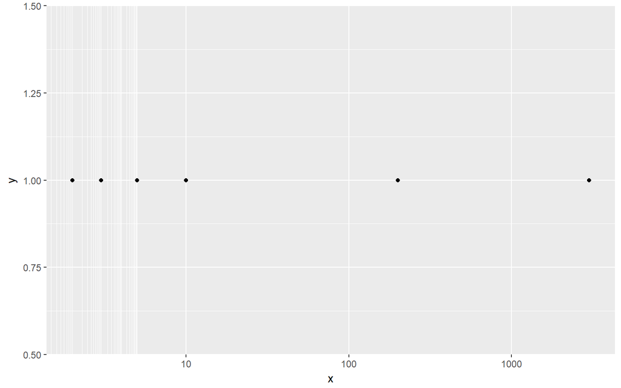

```r
mb <- as.numeric(1:10 %o% 10 ^ (0:4))
ggplot(df, aes(x, y)) +
  geom_point() +
  scale_x_log10(minor_breaks = log10(mb))
```

여기서 minor_breaks는 숫자 벡터를 제공해 보조 눈금선을 조정한다.

## 2.3 Exercises

1.Recreate the following graphic: 만약 scale_x_continuous가 아니라 scale_x_discrete을 하게 되면 축이 사라진다.

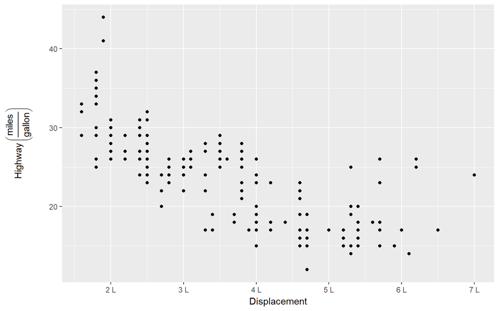

```r
ggplot(mpg, aes(displ, hwy)) +
  geom_point() +
  scale_x_continuous("Displacement", labels = scales::unit_format("L")) +
  scale_y_continuous(latex2exp::TeX("Highway \\left($\\frac{miles}{gallon}\\right)"))
```

```r
  #scale_y_continuous(quote(Highway*(frac(miles, gallon))))
```

2. Recreate the following plot:

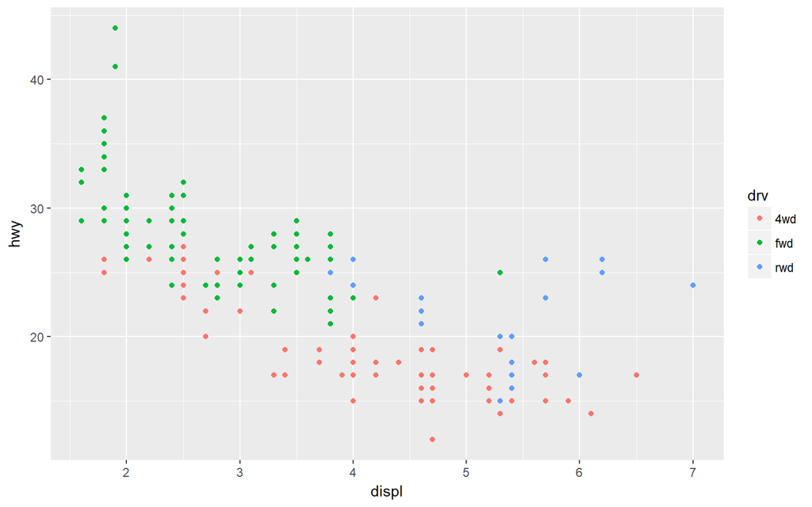

```r
ggplot(mpg, aes(displ, hwy, colour = drv)) +
  geom_point() +
  scale_color_discrete(labels = c("4" = "4wd", f = "fwd", r = "rwd"))
```

3. What label function allows you to create mathematical expressions?What label function converts 1 to 1st, 2 to 2nd, and so on?

```r
scales::ordinal(1:10)
```

```
##  [1] "1st"  "2nd"  "3rd"  "4th"  "5th"  "6th"  "7th"  "8th"  "9th"  "10th"
```

# 3 Legends

범례에만 적용되는 추가적인 옵션들이 있다. 범례는 축보다 좀 더 복잡하다. 그 이유는 다음과 같다

1. 범례는 여러개의 레이어로부터 다수의 미적요소를 나타낸다. 그리고 범례에서 보여지는 기호는 레이어에서 이용되는 기하객체에 기반하여 다양하다.
2. 축들은 항상 같은 곳에서 나타난다. 범례는 다른 장소에서도 나타날 수 있으므로 범례를 통제할만한 포괄적인 방법이 필요하다.
3. 범례는 상당히 수정할 수 있는 좀 더 디테일한 면을 가지고 있다. 수직 또는 수평으로 나타낼 것인가? 열의 수는? key의 크기는?

## 3.1 Layers and Legends

범례는 다수의 레이어로부터 기호를 그릴 필요가 있다. 디폴트로 하나의 레이어는 오직 상응하는 미적요소가 aes()와 함께 변수로 매핑될 때 나타난다. `show.legend:FALSE(또는 TRUE)`로 레이어에서 범례의 출력여부를 결정할 수 있다.

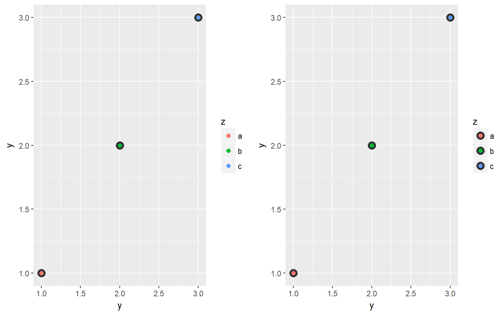

```r
df <- data.frame(x = 0, y = c(1,2,3), z=c("a","b","c"))
grid.arrange(ggplot(df, aes(y, y)) +
  geom_point(size = 4, colour = "grey20") +
  geom_point(aes(colour = z), size = 2),
ggplot(df, aes(y, y)) +
  geom_point(size = 4, colour = "grey20", show.legend = TRUE) +
  geom_point(aes(colour = z), size = 2), ncol = 2)
```

때때로 범례에 기하객체가 플랏에서의 기하객체와 다르게 나타났음을 바랄 수 있다. 이는 transparency or size를 오버플랏팅을 완화하는데 사용하고 또한 플랏에서 색상을 이용할 때 특히 유용하다. `guide_legend()`의 `override.aes` 매개변수를 이용하면 된다.

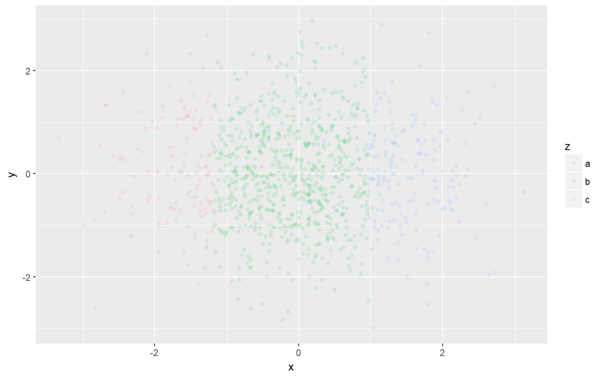

```r
norm <- data.frame(x = rnorm(1000), y = rnorm(1000))
norm$z <- cut(norm$x, 3, labels = c("a", "b", "c"))
ggplot(norm, aes(x, y)) +
  geom_point(aes(colour = z), alpha = 0.1)
```

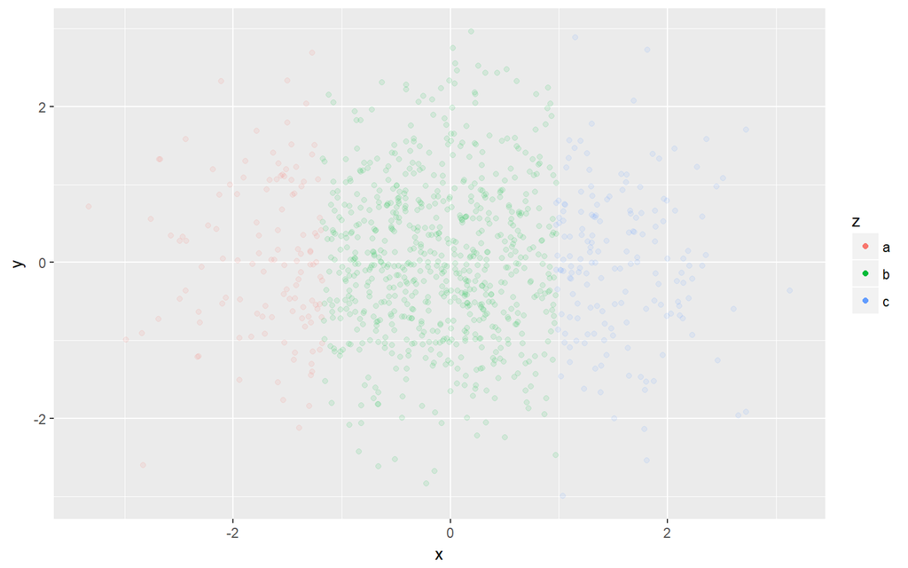

```r
ggplot(norm, aes(x, y)) +
  geom_point(aes(colour = z), alpha = 0.1) +
  guides(colour = guide_legend(override.aes = list(alpha = 1)))
```

ggplot는 가장 적은 수의 범례로 정확하게 미적요소를 전달하게 끔 되어있다.

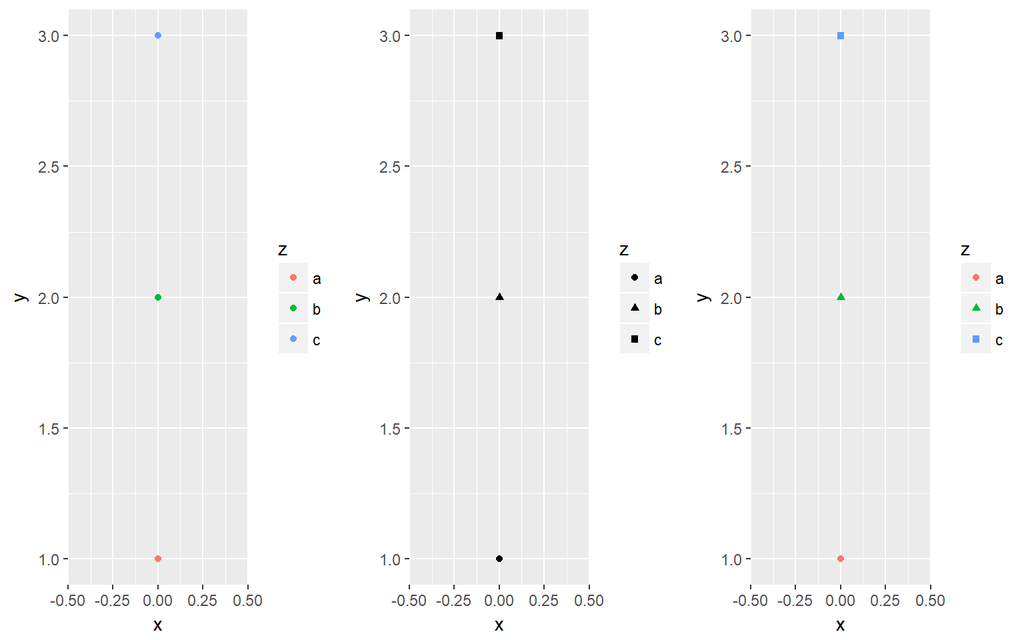

```r
grid.arrange(ggplot(df, aes(x, y)) + geom_point(aes(colour = z)),
ggplot(df, aes(x, y)) + geom_point(aes(shape = z)),
ggplot(df, aes(x, y)) + geom_point(aes(shape = z, colour = z)), ncol = 3)
```

범례를 합치기 위해, 반드시 같은 name을 가져야 한다. 만약 sclae의 이름중 하나를 변경하고 싶다면, scale 모두 바꿔야 한다.

## 3.2 Legend Layout

전반적인 범례의 상태에 영향을 주는 세팅의 수는 테마 시스템에 의하여 조정된다.

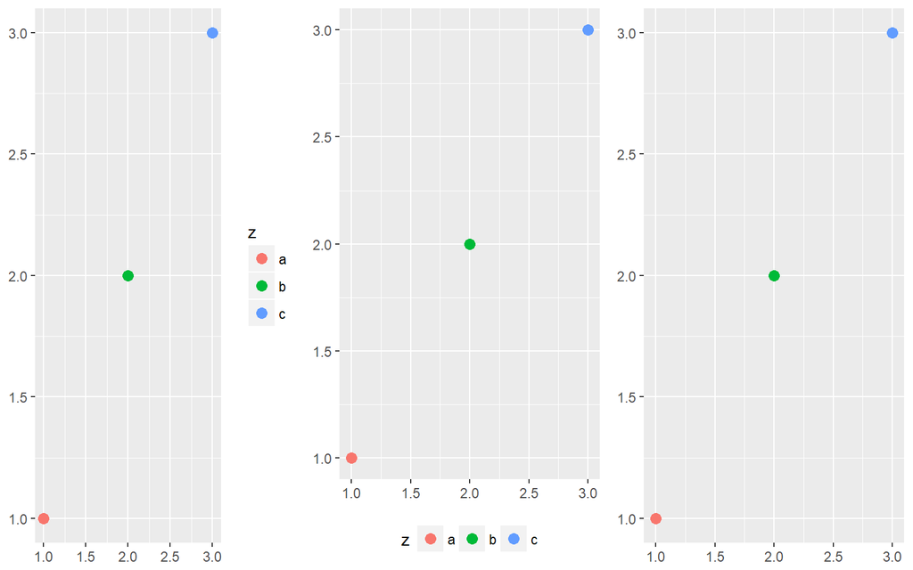

```r
df <- data.frame(x = 1:3, y = 1:3, z = c("a", "b", "c"))
base <- ggplot(df, aes(x, y)) +
  geom_point(aes(colour = z), size = 3) +
  xlab(NULL) +
  ylab(NULL)
grid.arrange(base + theme(legend.position = "right"), # the default
base + theme(legend.position = "bottom"),
base + theme(legend.position = "none"), ncol = 3)
```

- legend.direction : layout of items in legends(“horizontal” or “vertical”)
- legend.box : arrangement of multiple legends(“horizontal” or “vertical”)
- legend.box.just : justification of each legend within the overall bounding box, when there are multiple legends(“top”, “botton”, “left”, or “right”)
- legend.margin : 범례 주위 여백 제거 `theme(legend.margin = unit(0, "mm"))`

만약 플랏에 공백이 많다면 범례를 플랏 내에 위치시킬 수 있다. legend.position으로 가능.

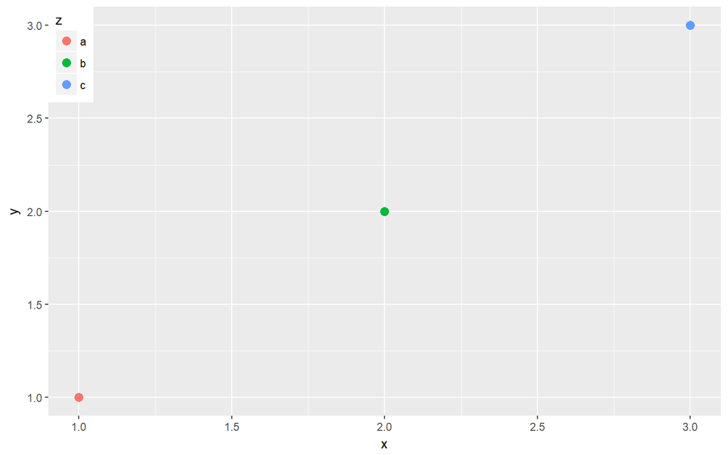

```r
base <- ggplot(df, aes(x, y)) +
  geom_point(aes(colour = z), size = 3)
base + theme(legend.position = c(0, 1), legend.justification = c(0, 1))
```

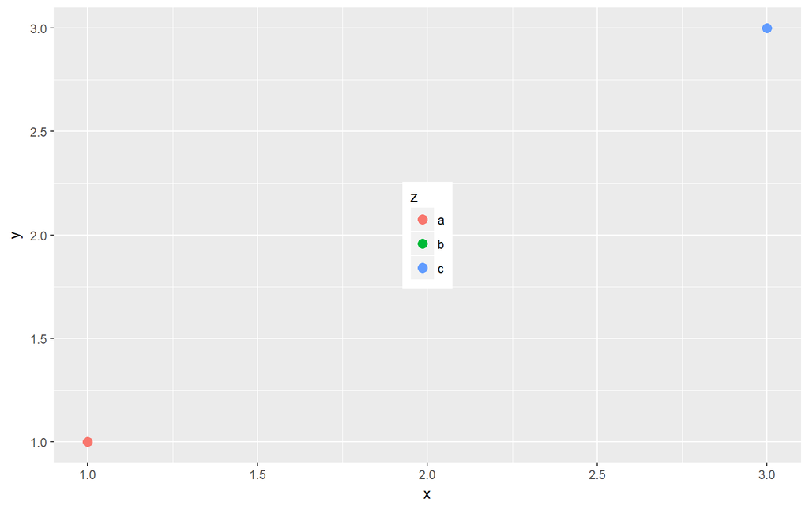

```r
base + theme(legend.position = c(0.5, 0.5), legend.justification = c(0.5, 0.5))
```

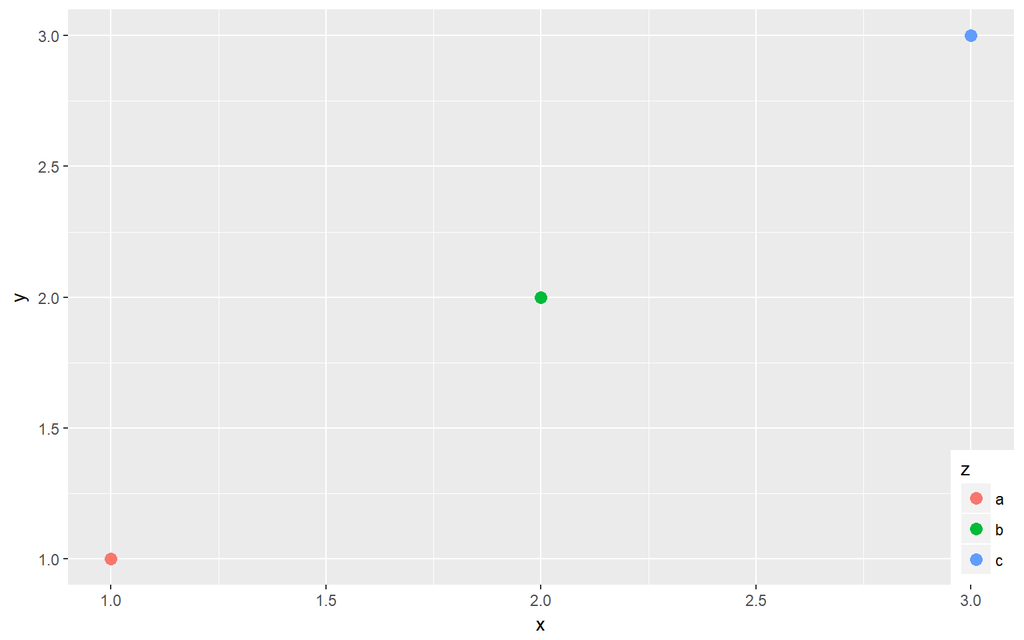

```r
base + theme(legend.position = c(1, 0), legend.justification = c(1, 0))
```

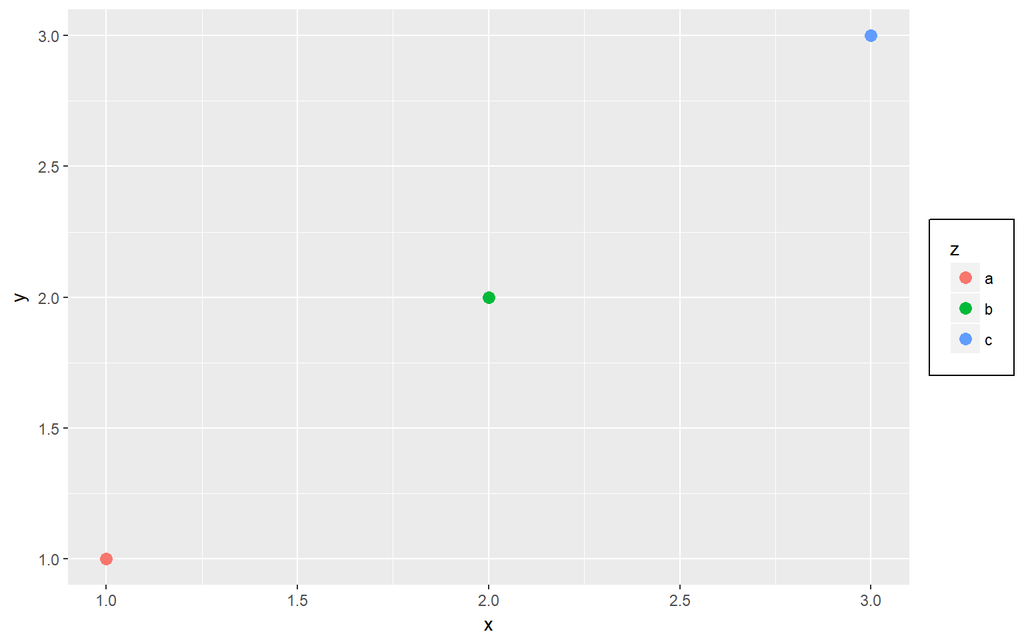

```r
base + theme(legend.box.background = element_rect(),legend.box.margin = margin(6, 6, 6, 6))
```

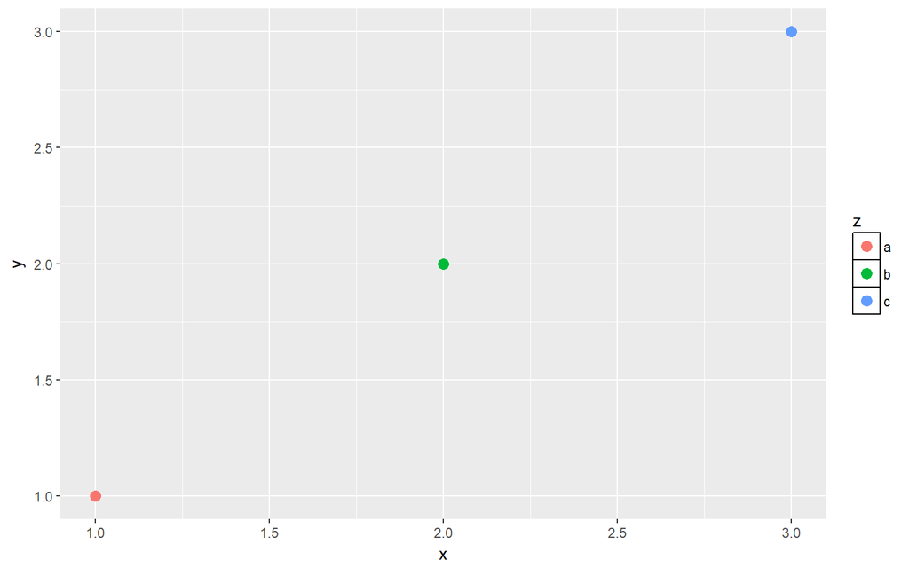

```r
base + theme(legend.key = element_rect(fill = "white", colour = "black"))
```

## 3.3 Guide Functions

guide 함수, `guide_colourbar()` 그리고 `guide_legend()`는 추가적인 범례의 세부사항의 통졔권을 준다. legend guide는 어느 미적요소에 이용되어지는 반면에 colour bar guide는 오직 continuous colour scales에만 이용될 수 있다.

default guide를 scale함수에 상응하는 guide 인자를 이용해서 오버라이딩 할 수 있다.

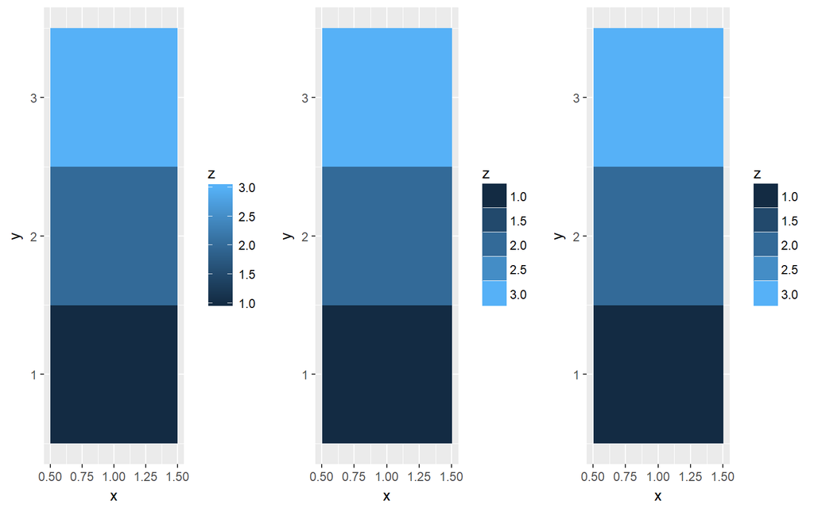

```r
df <- data.frame(x = 1, y = 1:3, z = 1:3)
base <- ggplot(df, aes(x, y)) + geom_raster(aes(fill = z))
grid.arrange(base,
base + scale_fill_continuous(guide = guide_legend()),
base + guides(fill = guide_legend()), ncol = 3)
```

**guide_legend()**

legend guide는 테이블의 개별 key를 보여준다. 가장 유용한 옵션은 :

- `nrow` or `ncol`. `byrow`

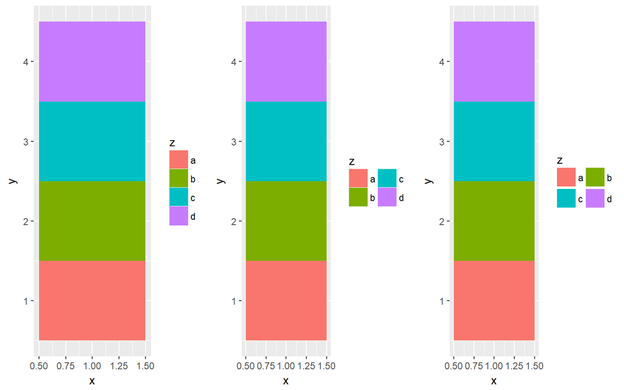

```r
df <- data.frame(x = 1, y = 1:4, z = letters[1:4])
# Base plot
p <- ggplot(df, aes(x, y)) + geom_raster(aes(fill = z))
grid.arrange(p,
p + guides(fill = guide_legend(ncol = 2)),
p + guides(fill = guide_legend(ncol = 2, byrow = TRUE)), ncol = 3)
```

- `reverse` key의 순서. 막대를 쌓을때 특히 유용하다. default stacking과 legend의 순서가 다를 때.

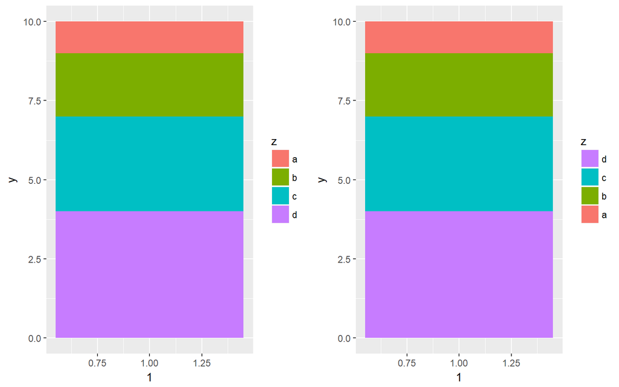

```r
p <- ggplot(df, aes(1, y)) + geom_bar(stat = "identity", aes(fill = z))
grid.arrange(p,
p + guides(fill = guide_legend(reverse = TRUE)), ncol =2)
```

- `override.aes` : 각 레이어로부터의 미적요소를 오버라이딩한다. 범례를 좀 더 시각적으로 두드러지게 할 때 유용하다.
- `keywidth and keyheight`

**guide_colourbar**

colour bar guide는 연속적인 색의 범위로 디자인 된다.

- `barwidth` and `barheight`은 막대의 size를 조정할 수 있다.
- `nbin`은 slices의 수를 조정한다. 20이 default
- `reverse`

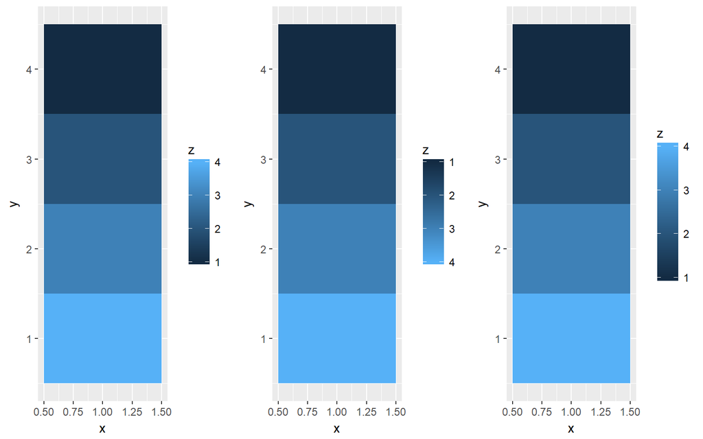

```r
df <- data.frame(x = 1, y = 1:4, z = 4:1)
p <- ggplot(df, aes(x, y)) + geom_tile(aes(fill = z))
grid.arrange(p,
p + guides(fill = guide_colorbar(reverse = TRUE)),
p + guides(fill = guide_colorbar(barheight = unit(4, "cm"))), ncol = 3)
```

guide_legend()에 비해 guide_colourbar()은 연속적인 색에서만 사용가능 하다는것을 기억하자.